# Homework 5

Weslley dos Santos Silva

# Definindo pesquisa:

Recentemente todos puderam acompanhar que a morte de George Floyd nos Estados Unidos desencadeou uma discussão social muito importante, principalmente em torno de Racismo, Preconceito e Violência policial. Dessa forma o objetivo é entender como os eventos atuais influenciaram nas buscas de conteúdos na internet.

Primeiro gostaria de apresentar de forma relativa a distribuição das pesquisas no último ano em torno de três palavras importantes para a conjuntura atual.

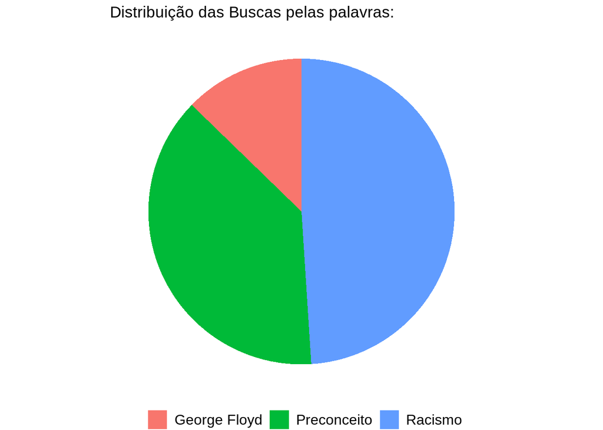

```r
# Racismo Geral
racismoGeral <- gtrends(
  keyword = c("Racismo","Preconceito","George Floyd"), geo = "BR", time = "today 12-m")
time_trend <- racismoGeral$interest_over_time
time_trend$hits = ifelse(time_trend$hits =="<1",0.5,time_trend$hits)
time_trend$date = as.Date(time_trend$date)

# Gráfico de Pizza
ggplot(time_trend, aes(x="", y=as.numeric(hits), fill=keyword, group = keyword)) +
  geom_bar(stat="identity", width=1) +
  coord_polar("y", start=0)+
  ggtitle("Distribuição das Buscas pelas palavras:")+
  theme_void() +
 theme(legend.title = element_blank(),legend.position="bottom",legend.text=element_text(size=12))
```

É claro que as pesquisas sobre racismos e problemas sociais sempre estão presentes no google, mas qual é o perfil dessas buscas e como é o comportamento dessas buscas por exemplo nos últimos 5 anos no Brasil? Podemos primeiramente olhar de forma geral e evidenciar a crescente das buscas no dia do assassinato de Geroge Floyd, 25 de maio.

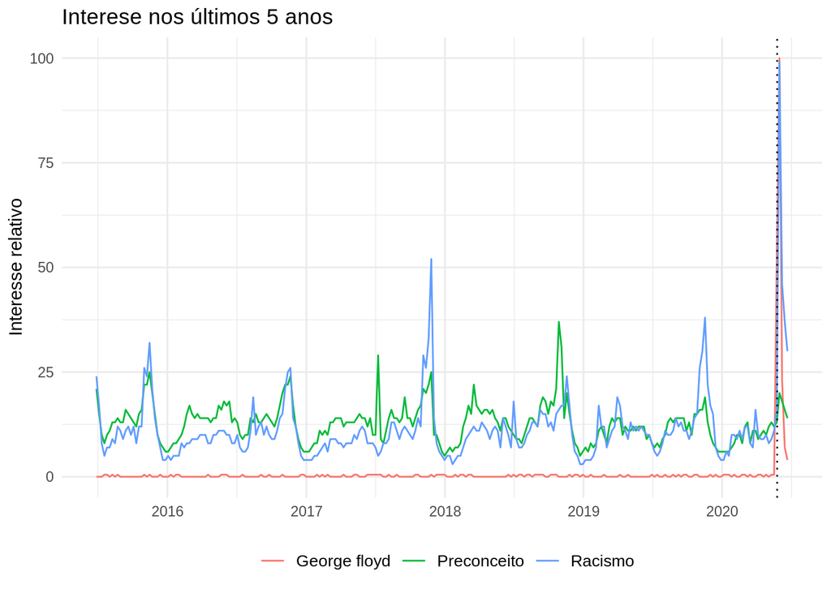

```r
racismo5Anos <- gtrends(
  keyword = c("Racismo","George floyd","Preconceito"), geo = "BR", time = "today+5-y")
CincoAnos_trend <- racismo5Anos$interest_over_time
CincoAnos_trend$hits = ifelse(CincoAnos_trend$hits =="<1",0.5,CincoAnos_trend$hits)
CincoAnos_trend$date = as.Date(CincoAnos_trend$date)

ggplot(data = CincoAnos_trend) +
  geom_line(aes(x = date, y =as.numeric(hits),group=keyword, color = keyword)) +
  geom_vline(xintercept = as.numeric(as.Date("2020-05-25")), linetype = 3, color="black") +
  labs(title = "Interese nos últimos 5 anos", y = "Interesse relativo") +
  theme_minimal()+
  theme(legend.position = "bottom",
        legend.title = element_blank(),
        legend.text=element_text(size=10),
        axis.title.x=element_blank())
```

A Seguir vou destacar com linhas pontilhadas em vermelho todas o dia 20 de Novembro de cada ano, Dia da Consciência Negra. E apesar de ser um pouco óbvio, podemos ver que sempre próximo a essas datas temos números maiores de busca pelo assunto mas vale destacar que essa data anualmente apresentava até o momento as máximas de procuras sobre os assuntos “Racismo” mas nem sempre sobre “Preconceito” visto que a discussão de preconceitos é muito mais abrangente em relação a grupos e minorias.

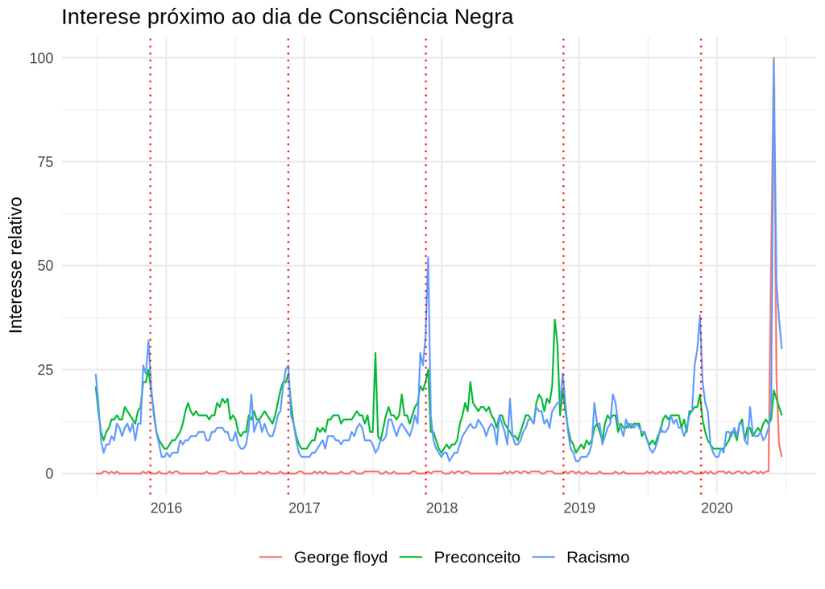

```r
ggplot(data = CincoAnos_trend) +
  geom_line(aes(x = date, y =as.numeric(hits),group=keyword, color = keyword)) +
  geom_vline(xintercept = as.numeric(as.Date("2019-11-20")), linetype = 3, color="red") +
  geom_vline(xintercept = as.numeric(as.Date("2018-11-20")), linetype = 3, color="red") +
  geom_vline(xintercept = as.numeric(as.Date("2017-11-20")), linetype = 3, color="red") +
  geom_vline(xintercept = as.numeric(as.Date("2016-11-20")), linetype = 3, color="red") +
  geom_vline(xintercept = as.numeric(as.Date("2015-11-20")), linetype = 3, color="red") +
  labs(title = "Interese próximo ao dia de Consciência Negra", y = "Interesse relativo") +
  theme_minimal()+
  theme(legend.position = "bottom",
        legend.title = element_blank(),
        legend.text=element_text(size=10),
        axis.title.x=element_blank())
```

# Interresse por região

Podemos destacar como foram as buscas protestos em cada estado durante o período de repercussão do assunto na mídia.

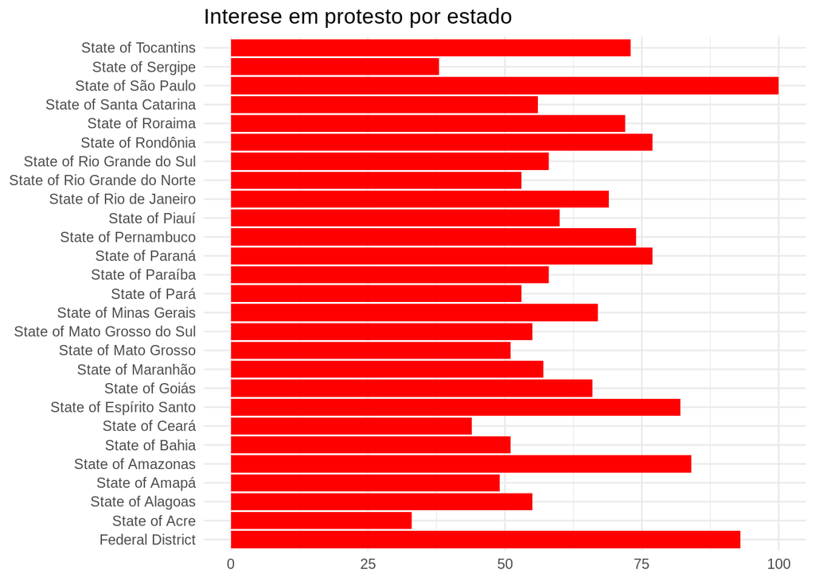

```r
Protesto <- gtrends(
  keyword = c("Protesto"), geo = "BR", time = "2020-05-25 2020-06-07")
time_trend <- Protesto$interest_over_time
time_trend$hits = ifelse(time_trend$hits =="<1",0.5,time_trend$hits)
time_trend$date = as.Date(time_trend$date)

region_trend <- Protesto$interest_by_region

ggplot(data = region_trend) +
  geom_bar(aes(x = location, weight = hits),fill = rainbow(1))+
  labs(title = "Interese em protesto por estado", x="Data", y="Interesse Relativo") +
  theme_minimal() +
  coord_flip()+
  theme(legend.position = "bottom",
        legend.title = element_blank(),
        legend.text=element_text(size=10),
        axis.title.y=element_blank(),
        axis.title.x=element_blank()
        )
```

Além de podermos utilizar das diferenças entre os ídices de buscas no Brasil e nos Estados Unidos como forma de avaliar as motivações da população com base no assunto mais comentado quanto aos problemas socias.

Com os gráficos abaixo podemos notar que no Brasil o índice relativo de pesquisas por racismo é maior do que nos Estados Unidos, mas também revelam sua sasonalidade de pesquisas, que o conteúdo é muito mais procurados próximo a eventos e datas relacionados a população preta, como foi analisado acima.  
Temos diversos meios de perceber que a luta da população negra no Brasil não tinha o seu foco na violência policial, uma vez que temos frequentemente jovens negros sendo mortos e não são feitas comossões sociais tão intensas.

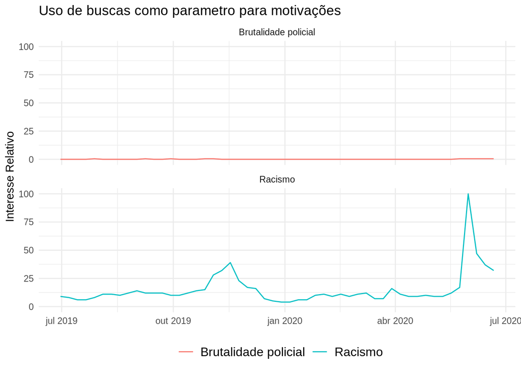

```r
# Definindo a pesquisa
keywords=c("Racismo","Brutalidade policial")
country=c("BR")
time = "today 12-m"

trends = gtrends(keyword=keywords, geo=country, time = time)
time_trend=trends$interest_over_time
time_trend$hits = ifelse(time_trend$hits=="<1",0.5,time_trend$hits)

plot <-ggplot(data=time_trend)+
  geom_line(aes(x=date,y=as.numeric(hits),group=keyword,col=keyword))+
  labs(title = "Uso de buscas como parametro para motivações", x="Data", y="Interesse Relativo") +
  theme_minimal()+
  theme(legend.title = element_blank(),
        legend.position="bottom",
        legend.text=element_text(size=12),
        axis.title.x=element_blank())+
  facet_wrap(. ~ keyword, ncol = 1)
plot
```

Por sua nos Estados Unidos os protestos se desendadearam apartir da violência policial, então esse é um dos assuntos que tiveram um crescimento de buscas, pontuando o racismo e a violência policial.

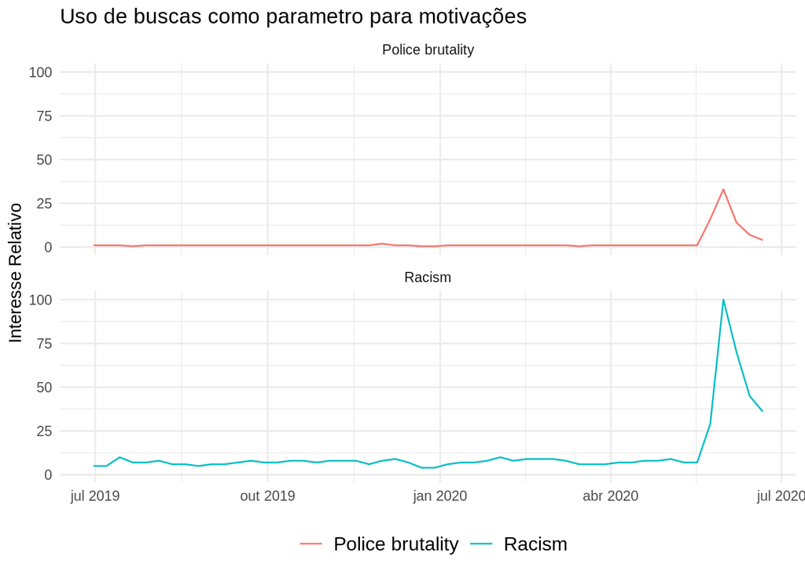

```r
keywords=c("Racism","Police brutality")
country=c("US")

trends = gtrends(keyword=keywords, geo=country, time = time)
time_trend=trends$interest_over_time
time_trend$hits = ifelse(time_trend$hits=="<1",0.5,time_trend$hits)

plot <-ggplot(data=time_trend)+
  geom_line(aes(x=date,y=as.numeric(hits),group=keyword,col=keyword))+
  labs(title = "Uso de buscas como parametro para motivações", x="Data", y="Interesse Relativo") +
  theme_minimal()+
  theme(legend.title = element_blank(),
        legend.position="bottom",
        legend.text=element_text(size=12),
        axis.title.x=element_blank())+
  facet_wrap(. ~ keyword, ncol = 1)
plot
```

# Conclusão

O Objetivo desse trabalho foi demonstrar como a forma de posicionamento popular pode mudar completamente a forma de buscas e acesso a informação na era da mídia digital, mas pontuar que ainda é necessário muitos avanços quanto as discussões sociais e enfrentamento do racismo.